# Machine Learning Project R Markdown - Active Transportation Prevelence Prediction

Tate HubkaRao

2023-08-17

### Table of Contents:

1. Import library for all relevant packages
2. Import the datasets from ArcGIS
3. Clean data and set the seed (cleaning done in STATA)
4. Split data into city-specific and national datasets
5. National Analysis 5a) Split data into training and testing sets 5b) Build the model 5c) Predict outcomes 5d) Evaluate model 5e) Prune tree 5f) Evaluate prunes
6. City Specific Analysis 6a) Split data into training and testing sets 6b) Build the model 6c) Predict outcomes 6d) Evaluate model 6e) Prune tree 6f) Evaluate prunes
7. Compare National and City-specific trees

## Step 1: Import libraries

R Version:

```
## [1] "R version 4.5.3 (2026-03-11)"
```

Included packages:

```
##  [1] "reshape2"     "data.table"   "basictabler"  "table1"       "randomForest"
##  [6] "vip"          "tree"         "haven"        "caret"        "lattice"
## [11] "lubridate"    "stringr"      "forcats"      "purrr"        "readr"
## [16] "tidyr"        "ggplot2"      "dplyr"        "rpart.plot"   "rpart"
## [21] "plyr"         "conflicted"   "stats"        "graphics"     "grDevices"
## [26] "utils"        "datasets"     "methods"      "base"
```

## Step 2: Descriptive statistics

Here, we import the cleaned dataframe from STATA, called ‘school and catchment data.dta’. This includes all the counts from all the schools, that fit the inclusion criteria.

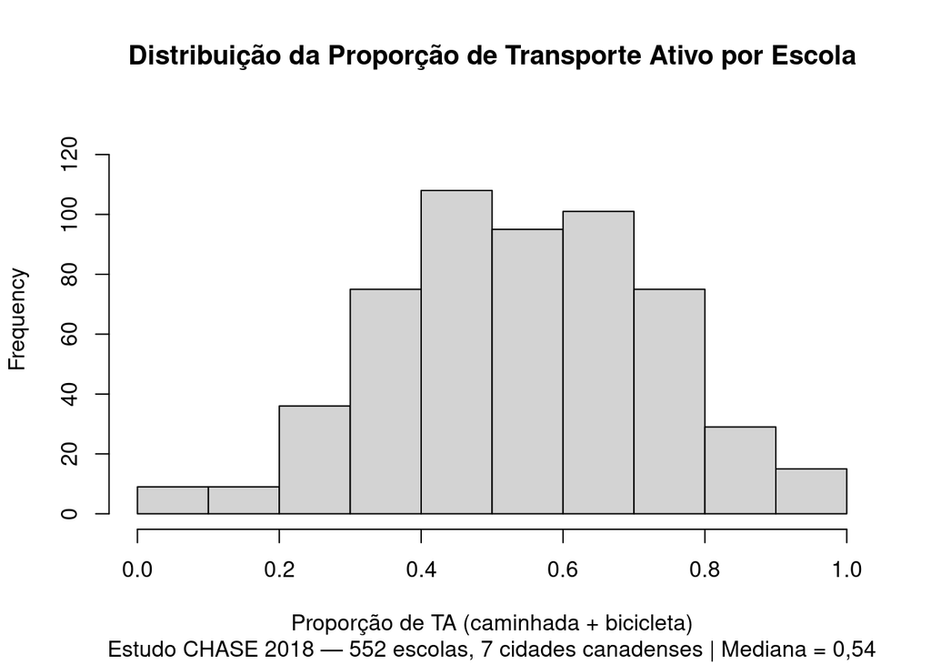

As we can see, this outcome variable is fairly normally distributed.

This chunk creates a table showing the descriptive statistics of each city.

Table 1. Characteristics of Catchment Zone, by city/region

|  | Calgary (N=125) | Laval (N=50) | Montreal (N=67) | Peel (N=71) | Toronto (N=96) | Surrey (N=76) | Vancouver (N=67) | Overall (N=552) |
| --- | --- | --- | --- | --- | --- | --- | --- | --- |
| Area (km^2) | 2.48 (1.66) | 12.3 (25.2) | 6.85 (28.5) | 3.00 (3.12) | 3.14 (3.59) | 1.39 (0.875) | 1.62 (1.12) | 3.83 (12.9) |
| # of children 0-17 years old | 1740 (1150) | 4440 (8580) | 5240 (15800) | 1920 (864) | 1200 (395) | 1390 (860) | 1250 (459) | 2230 (6250) |
| Density of children 0-17 years old | 741 (349) | 629 (364) | 1490 (755) | 968 (603) | 750 (520) | 1350 (1760) | 923 (393) | 959 (852) |
| Child AT Collisions | NA (NA) | NA (NA) | NA (NA) | NA (NA) | NA (NA) | NA (NA) | NA (NA) | NA (NA) |
| Missing | 125 (100%) | 50 (100%) | 67 (100%) | 71 (100%) | 96 (100%) | 76 (100%) | 67 (100%) | 552 (100%) |
| Proportion of active transportation | 0.438 (0.140) | 0.395 (0.221) | 0.697 (0.181) | 0.544 (0.157) | 0.512 (0.150) | 0.647 (0.175) | 0.617 (0.135) | 0.542 (0.189) |
| Proportion of recent (<5yrs) immigrants | 0.0706 (0.0412) | 0.0318 (0.0201) | 0.0740 (0.0397) | 0.0711 (0.0328) | 0.0665 (0.0343) | 0.0719 (0.0468) | 0.0569 (0.0230) | 0.0654 (0.0380) |
| Number of schools | 2.82 (1.60) | 9.38 (18.3) | 12.0 (38.7) | 1.00 (0) | 1.68 (0.923) | 3.07 (2.47) | 1.57 (0.802) | 3.98 (15.0) |
| Length of roadway | 37.9 (22.4) | 135 (224) | 137 (426) | 40.8 (31.0) | 36.3 (14.0) | 20.8 (6.43) | 29.4 (9.81) | 70.0 (207) |
| Missing | 81 (64.8%) | 18 (36.0%) | 33 (49.3%) | 44 (62.0%) | 72 (75.0%) | 53 (69.7%) | 62 (92.5%) | 363 (65.8%) |
| # of pedestrians | 54.9 (32.4) | 54.2 (46.1) | 140 (78.4) | 148 (113) | 129 (68.4) | 160 (145) | 116 (57.3) | 112 (92.3) |
| Proportion of pedestrians | 0.338 (0.115) | 0.326 (0.187) | 0.637 (0.174) | 0.504 (0.159) | 0.492 (0.152) | 0.611 (0.168) | 0.560 (0.126) | 0.486 (0.189) |
| # of bicyclists | 13.6 (16.1) | 8.88 (11.0) | 8.19 (9.80) | 7.21 (7.73) | 3.52 (5.07) | 4.80 (6.08) | 8.36 (11.4) | 8.10 (11.2) |
| Proportion of bicyclists | 0.0769 (0.0660) | 0.0605 (0.0713) | 0.0379 (0.0411) | 0.0307 (0.0344) | 0.0136 (0.0156) | 0.0218 (0.0251) | 0.0379 (0.0436) | 0.0414 (0.0516) |

Note: Data are the mean (sd) averaged accross all Catchment Zones in each city/region.

Table 1. Characteristics of Catchment Zone, by city/region

|  | Calgary (N=125) | Laval (N=50) | Montreal (N=67) | Peel (N=71) | Toronto (N=96) | Surrey (N=76) | Vancouver (N=67) | Overall (N=552) |
| --- | --- | --- | --- | --- | --- | --- | --- | --- |
| Area (km^2) | 2.13 (1.02) | 3.11 (7.74) | 1.12 (2.23) | 2.01 (2.01) | 1.61 (2.04) | 1.07 (1.02) | 1.35 (0.897) | 1.77 (1.73) |
| Walkscore | 49.0 (20.0) | 58.5 (33.0) | 82.0 (17.0) | 49.0 (18.5) | 45.0 (23.5) | 64.0 (29.8) | 78.0 (25.5) | 56.0 (31.5) |
| Number of (0-17 yrs) children | 1440 (1200) | 1760 (2180) | 1540 (1360) | 1850 (1280) | 1160 (535) | 1230 (833) | 1180 (658) | 1390 (972) |
| Population density | 3260 (1500) | 3040 (2350) | 7560 (5370) | 3960 (2980) | 3410 (3350) | 5850 (3240) | 5780 (3770) | 4160 (3330) |
| Density of children | 642 (470) | 602 (441) | 1400 (909) | 837 (726) | 695 (693) | 1010 (740) | 908 (537) | 824 (682) |
| School enrollment | 324 (244) | 422 (240) | 422 (213) | 428 (235) | 412 (173) | 320 (237) | 359 (202) | 381 (229) |
| Proportion of children using AT | 0.418 (0.169) | 0.425 (0.332) | 0.737 (0.233) | 0.534 (0.225) | 0.514 (0.179) | 0.645 (0.277) | 0.632 (0.175) | 0.540 (0.275) |
| Child AT-MVCs | NA (NA) | NA (NA) | NA (NA) | NA (NA) | NA (NA) | NA (NA) | NA (NA) | NA (NA) |
| Missing | 125 (100%) | 50 (100%) | 67 (100%) | 71 (100%) | 96 (100%) | 76 (100%) | 67 (100%) | 552 (100%) |
| Density of immigrant population | 193 (260) | 62.5 (134) | 537 (566) | 257 (373) | 219 (292) | 339 (539) | 288 (286) | 245 (373) |
| Density of multihome buildings | 174 (328) | 224 (468) | 2980 (2910) | 218 (534) | 495 (673) | 1290 (1590) | 1560 (1730) | 560 (1340) |
| Number of schools | 2.00 (2.00) | 3.50 (7.00) | 3.00 (4.50) | 1.00 (0) | 1.00 (1.00) | 2.00 (2.00) | 1.00 (1.00) | 2.00 (2.00) |
| Density of roadway | 13.5 (2.07) | 9.95 (7.00) | 16.1 (4.51) | 9.72 (3.43) | 10.1 (6.91) | 13.0 (3.65) | 23.9 (7.73) | 13.0 (5.48) |
| Missing | 81 (64.8%) | 18 (36.0%) | 33 (49.3%) | 44 (62.0%) | 72 (75.0%) | 53 (69.7%) | 62 (92.5%) | 363 (65.8%) |

Note: Data are the median (iqr) accross all Catchment Zones in each city/region.

## Step 3: Set the seed

To ensure reproducibility of these models, we will set the seed prior to any datawork. We will set the seed at 15.

## Step 4: Split data into National and City-Specific datasets

This code removes all variations of the outcome variable.

## Step 5: National Analysis

We will first conduct our analysis on all of the data, looking at it from a Canada-wide perspective.

## Step 5a: Split data into training and testing data

We will be splitting the dataset into two components, the training dataset and the testing dataset. Each dataset will have a portion of the full dataset (80% and 20% respectively).

## Step 5b: Build the model

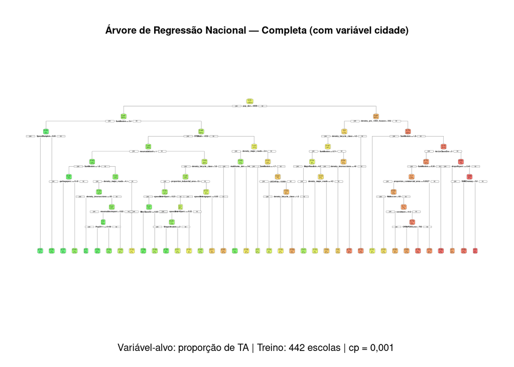

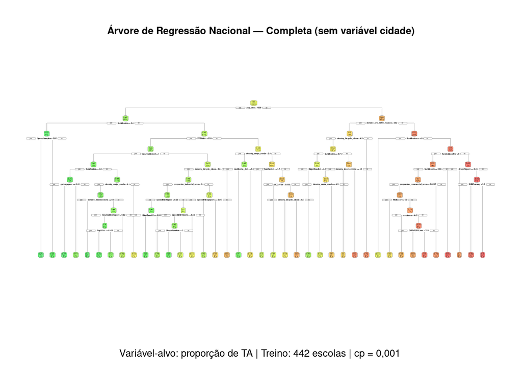

## Step 7: Predict the outcomes and measure performance

First, we will determine how accurate the model was on the training data.

Here are some outputs providing some information on the accuracy of the predicted model on the test data.

[interactive chart not shown]

We can also get a figure showing the relative error in the R-Squared value based on differing levels of the complexity parameter (cp). By changing the cp in our model, we can influence how many splits occur in our tree. With larger cp values, we can limit the number of splits by ensuring the model only splits if the overall R-squared increases by the cp. This is based on the training data.

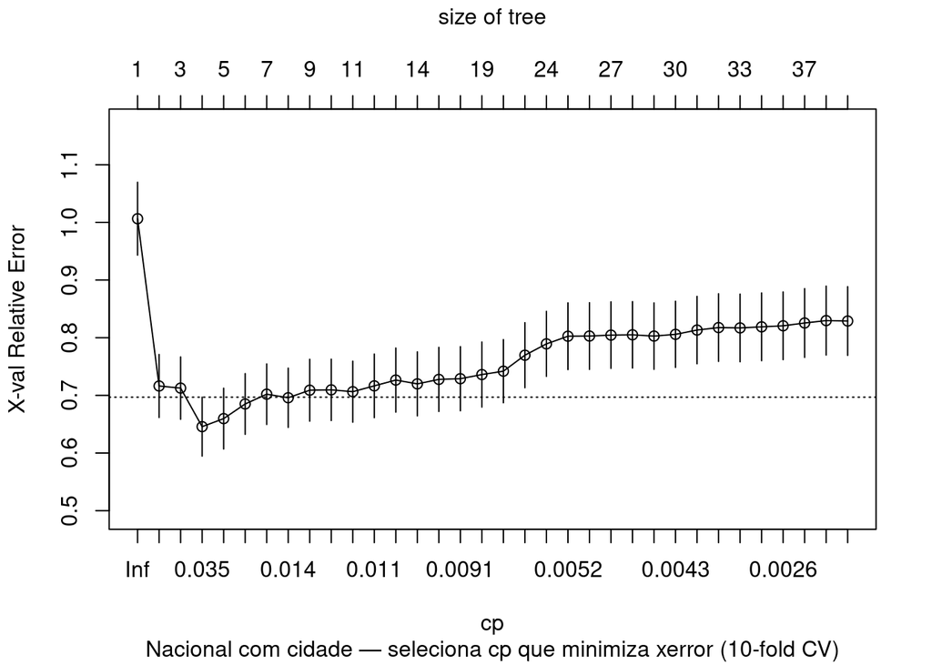

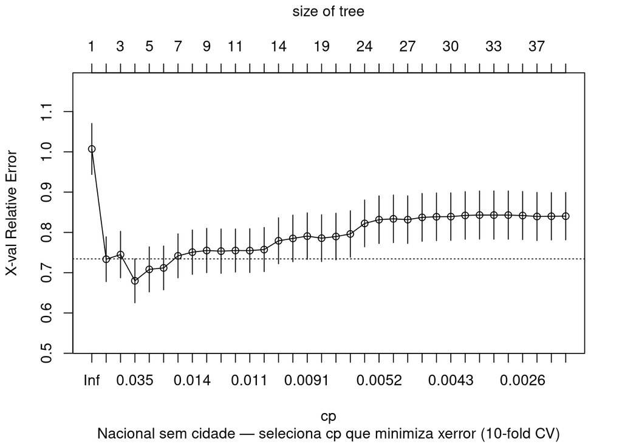

## Step 8: Measure performance

Measure the importance of each variable

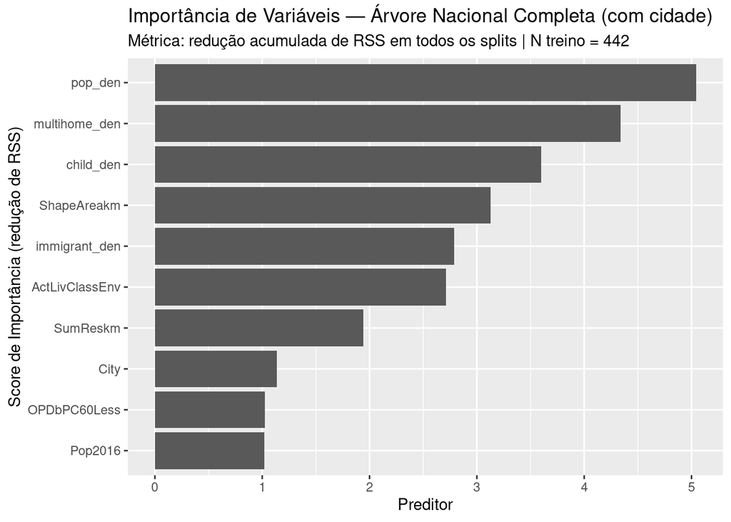

[figure not shown]

```
## # A tibble: 74 × 2
##    Variable       Importance
##    <chr>               <dbl>
##  1 pop_den              5.04
##  2 multihome_den        4.34
##  3 child_den            3.60
##  4 ShapeAreakm          3.13
##  5 immigrant_den        2.79
##  6 ActLivClassEnv       2.71
##  7 SumReskm             1.94
##  8 City                 1.14
##  9 OPDbPC60Less         1.03
## 10 Pop2016              1.02
## # ℹ 64 more rows
```

```
## # A tibble: 74 × 2
##    Variable       Importance
##    <chr>               <dbl>
##  1 pop_den              5.04
##  2 multihome_den        4.34
##  3 child_den            3.60
##  4 ShapeAreakm          3.13
##  5 ActLivClassEnv       3.08
##  6 immigrant_den        2.79
##  7 SumReskm             1.94
##  8 City                 1.14
##  9 OPDbPC60Less         1.03
## 10 Pop2016              1.02
## # ℹ 64 more rows
```

## Step 9: Prune tree and evaluate

## Prune the tree

Now that we have a full tree, and evaluated it’s performance, we can see whether pruning it a bit helps.

So here is our final tree:

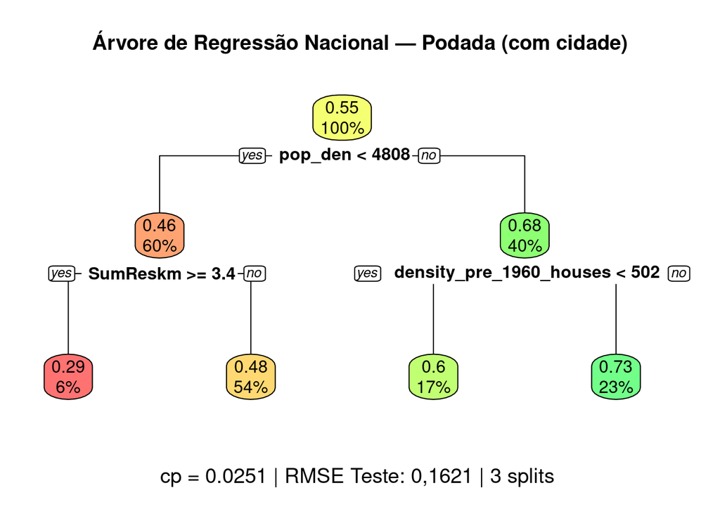

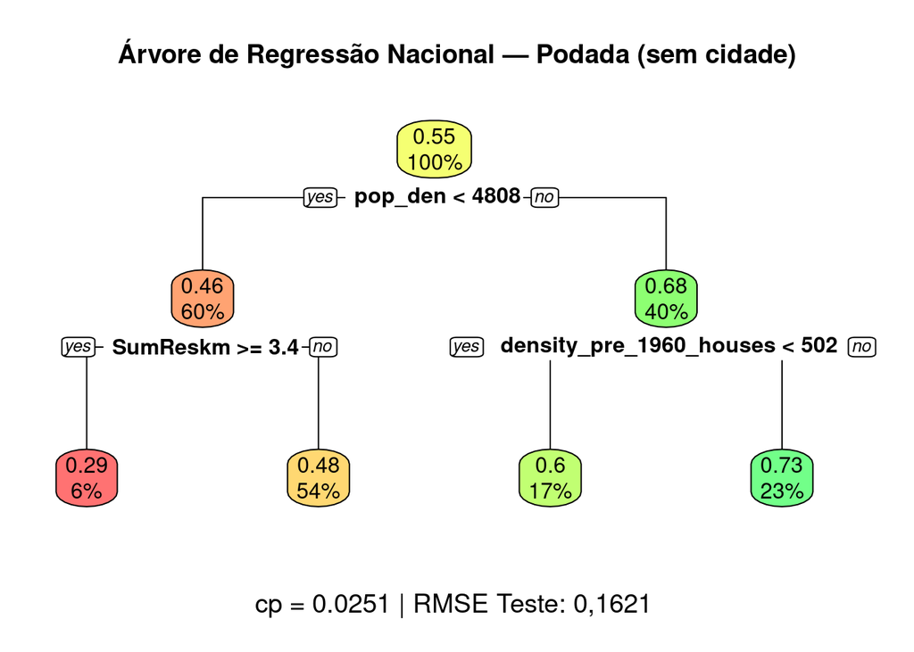

Measure the importance of each variable

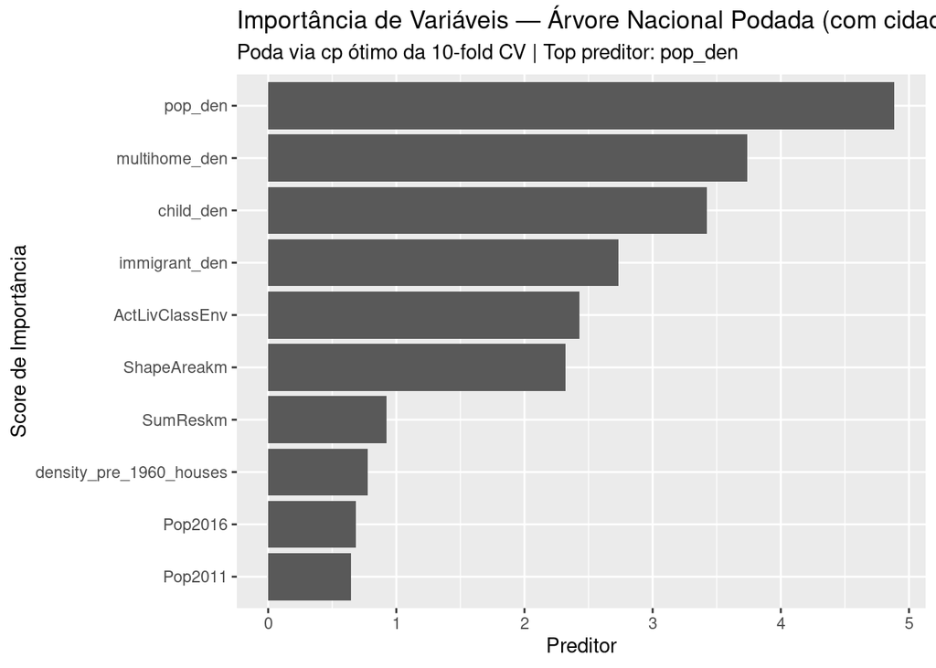

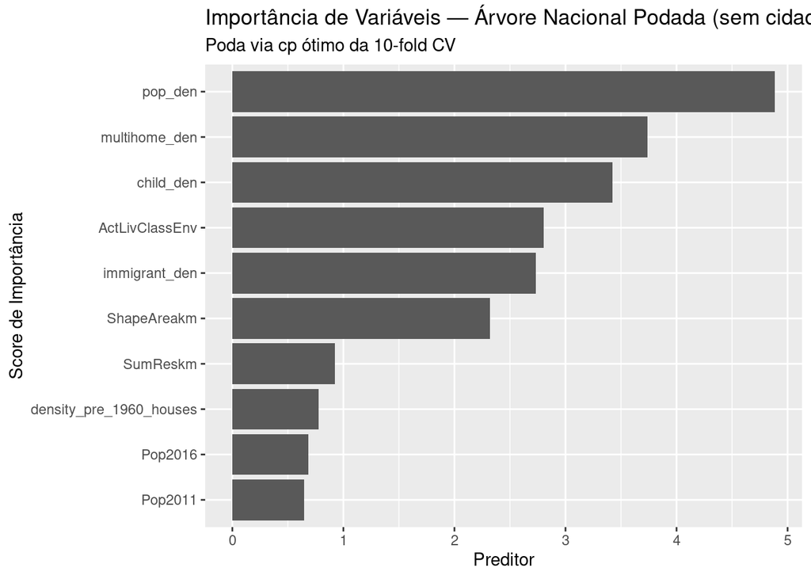

```
## # A tibble: 17 × 2
##    Variable                Importance
##    <chr>                        <dbl>
##  1 pop_den                      4.89
##  2 multihome_den                3.74
##  3 child_den                    3.42
##  4 immigrant_den                2.73
##  5 ActLivClassEnv               2.43
##  6 ShapeAreakm                  2.32
##  7 SumReskm                     0.922
##  8 density_pre_1960_houses      0.776
##  9 Pop2016                      0.683
## 10 Pop2011                      0.649
## 11 OPDbPC60Less                 0.620
## 12 SUMIntersection              0.614
## 13 MinorRoadkm                  0.580
## 14 city                         0.548
## 15 City                         0.548
## 16 BikeClassAll                 0.478
## 17 Walkscore                    0.455
```

```
## # A tibble: 16 × 2
##    Variable                Importance
##    <chr>                        <dbl>
##  1 pop_den                      4.89
##  2 multihome_den                3.74
##  3 child_den                    3.42
##  4 ActLivClassEnv               2.80
##  5 immigrant_den                2.73
##  6 ShapeAreakm                  2.32
##  7 SumReskm                     0.922
##  8 density_pre_1960_houses      0.776
##  9 Pop2016                      0.683
## 10 Pop2011                      0.649
## 11 OPDbPC60Less                 0.620
## 12 SUMIntersection              0.614
## 13 MinorRoadkm                  0.580
## 14 City                         0.548
## 15 BikeClassAll                 0.478
## 16 Walkscore                    0.455
```

[interactive chart not shown]

### City-specific models

We will redo all of the above, but for each city seperatly. This will allow us to compare them, and see whether a prediction model for all cities would be better or worse, than a city-specific one.

## Step 6a) Split data into training and testing sets

## Step 6b) Build the model

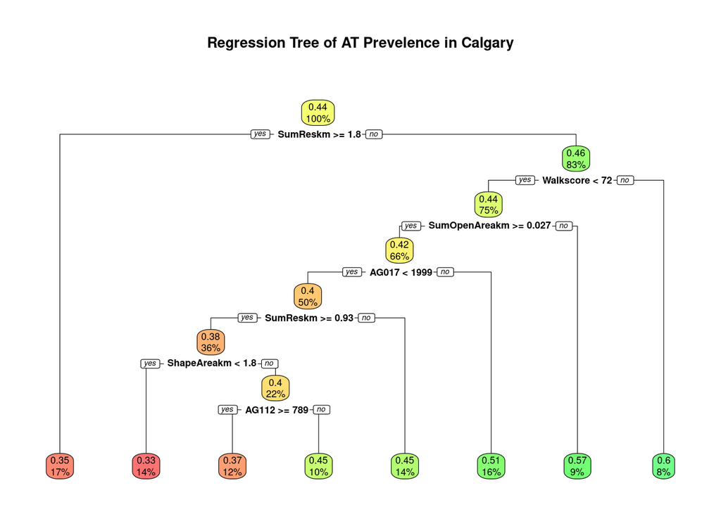

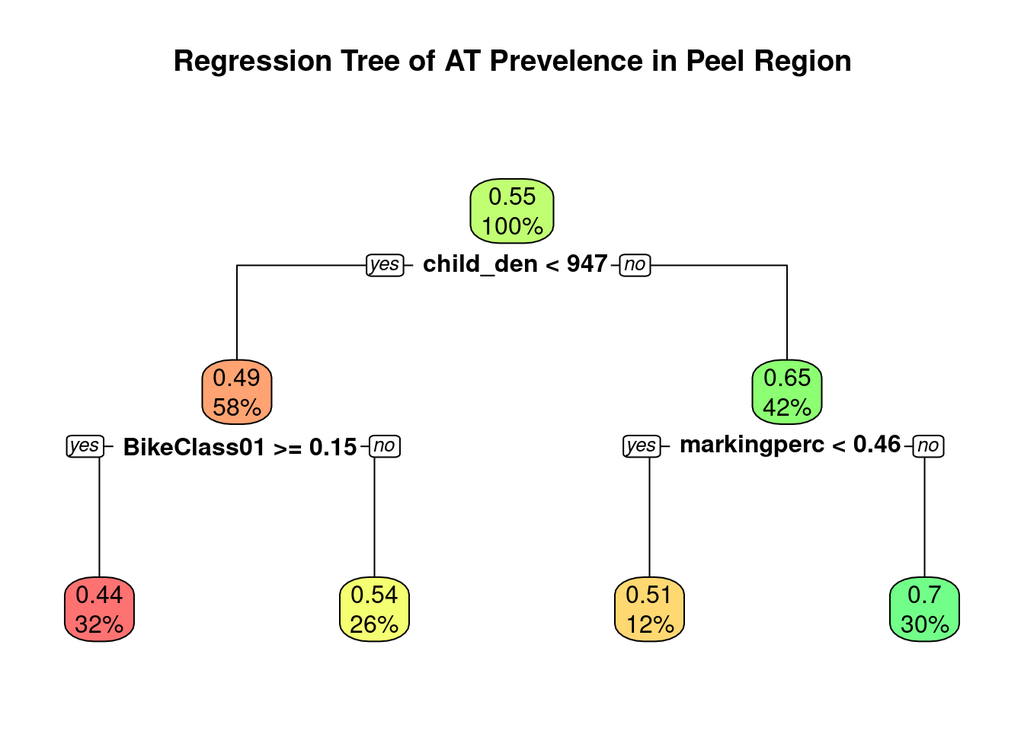

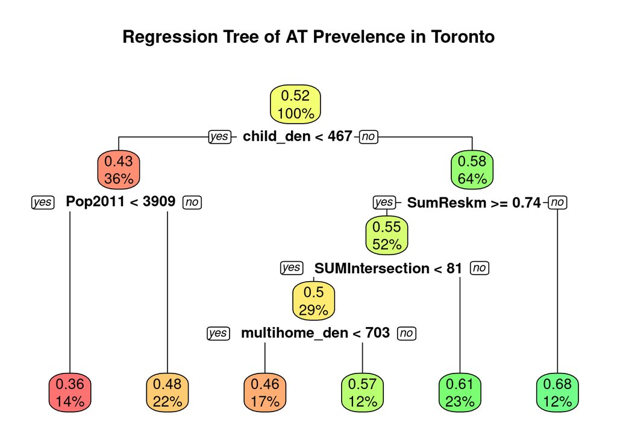

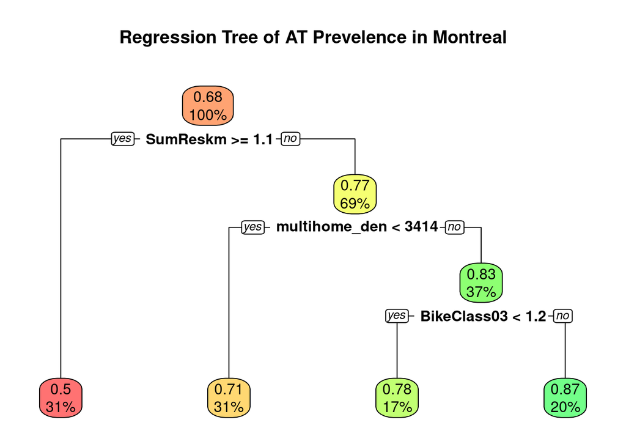

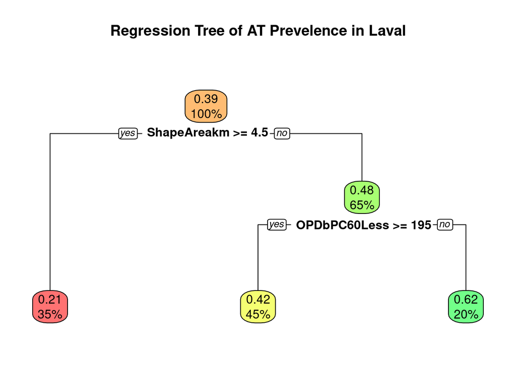

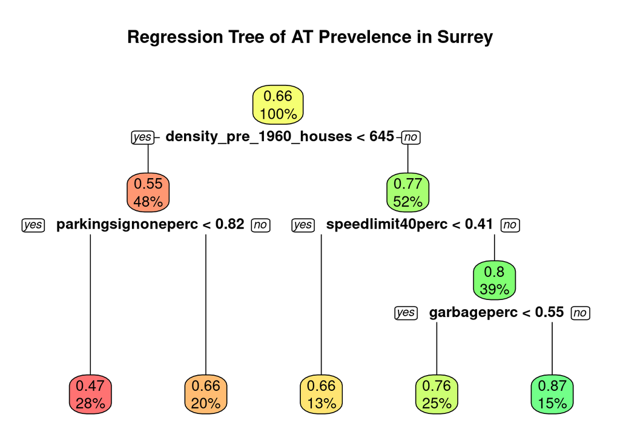

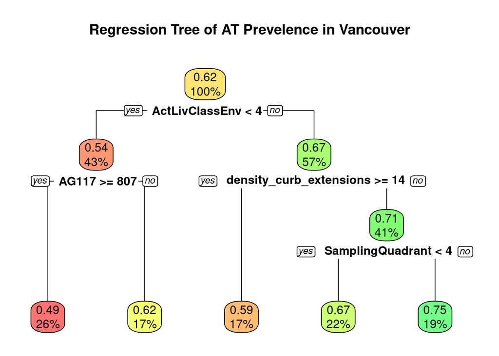

## Step 6c) Predict outcomes

## Step 6d) Evaluate model

[interactive chart not shown]

Measure the importance of each variable

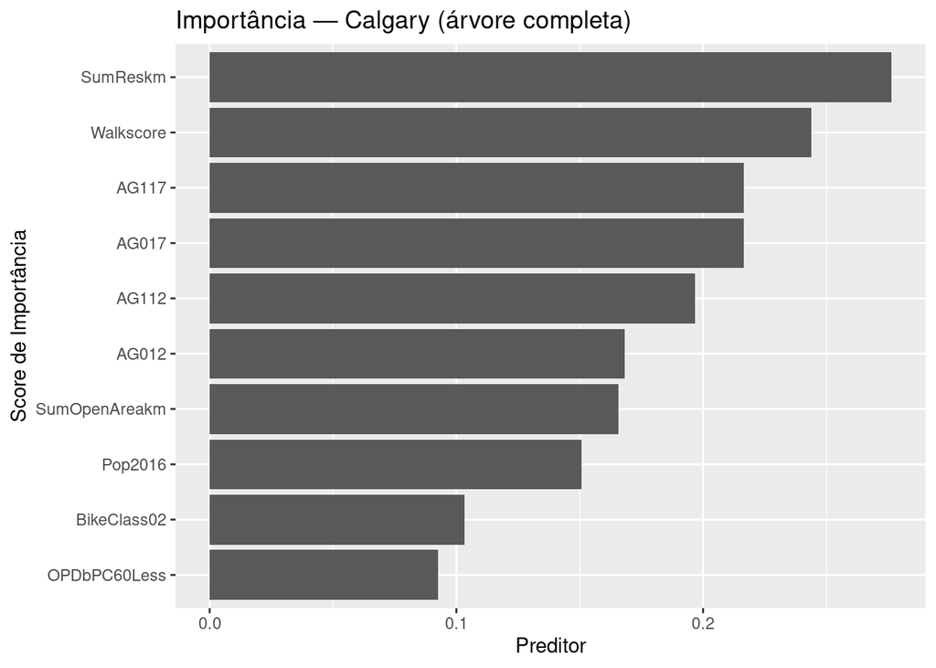

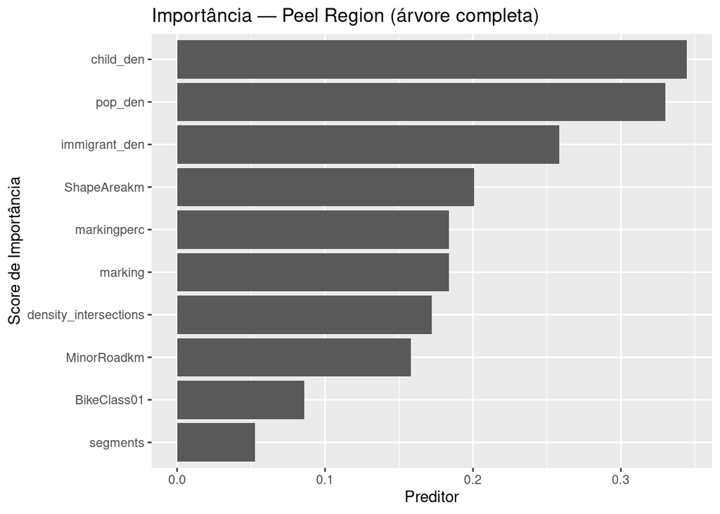

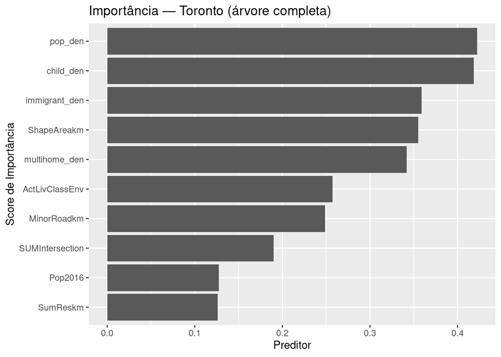

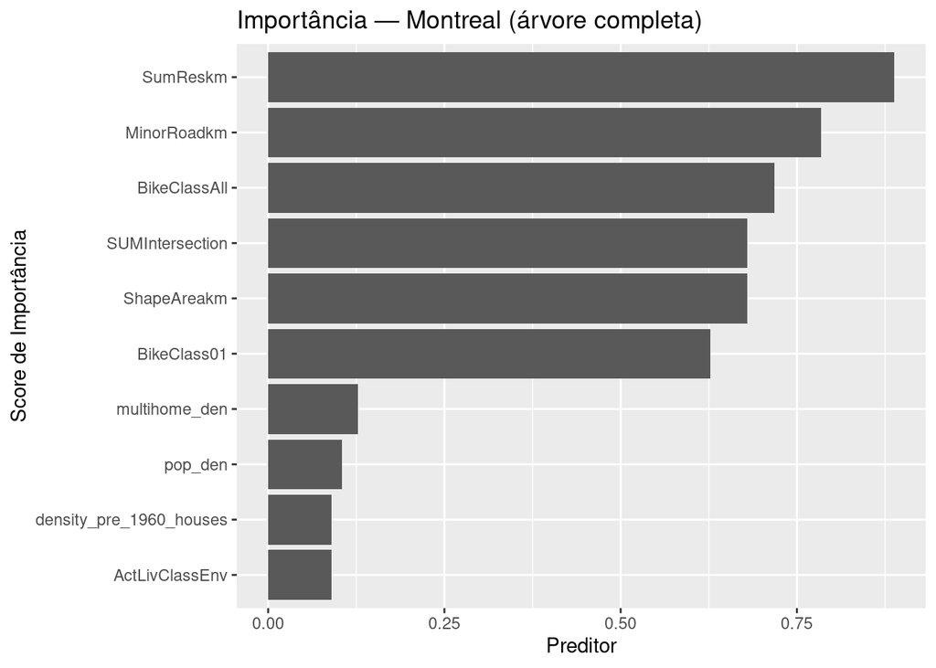

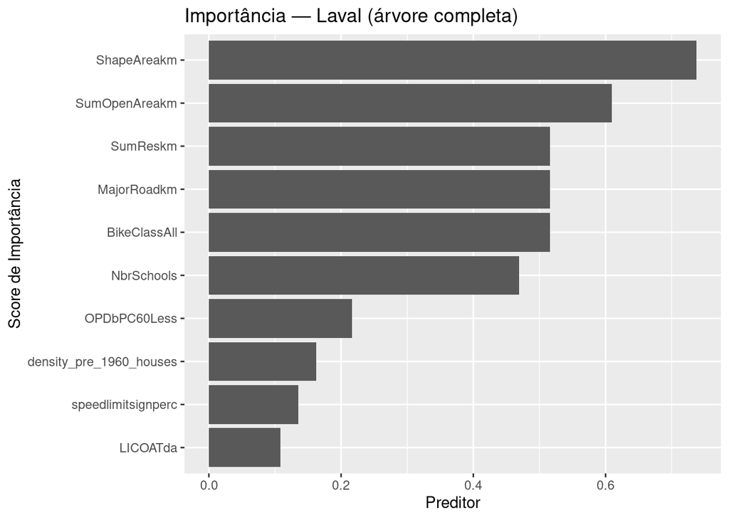

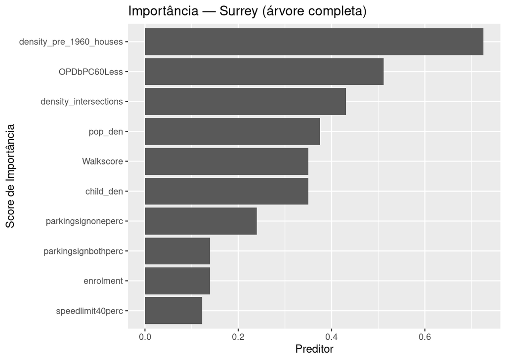

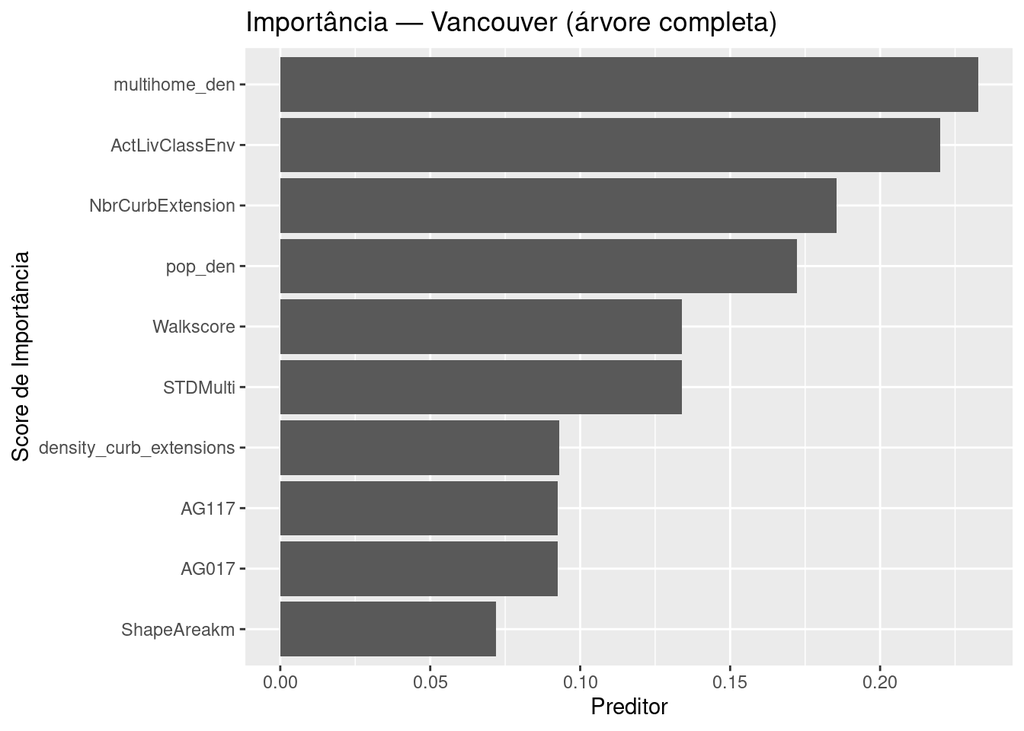

```
## # A tibble: 26 × 2
##    Variable      Importance
##    <chr>              <dbl>
##  1 SumReskm          0.276
##  2 Walkscore         0.244
##  3 AG017             0.217
##  4 AG117             0.217
##  5 AG112             0.197
##  6 AG012             0.168
##  7 SumOpenAreakm     0.166
##  8 Pop2016           0.151
##  9 BikeClass02       0.103
## 10 OPDbPC60Less      0.0926
## # ℹ 16 more rows
```

```
## # A tibble: 18 × 2
##    Variable              Importance
##    <chr>                      <dbl>
##  1 child_den                 0.344
##  2 pop_den                   0.330
##  3 immigrant_den             0.258
##  4 ShapeAreakm               0.201
##  5 marking                   0.184
##  6 markingperc               0.184
##  7 density_intersections     0.172
##  8 MinorRoadkm               0.158
##  9 BikeClass01               0.0860
## 10 segments                  0.0525
## 11 sidewalkbothperc          0.0525
## 12 sidewalkoneperc           0.0525
## 13 Walkscore                 0.0525
## 14 ISPH1116                  0.0459
## 15 STDMulti                  0.0459
## 16 SumOpenAreakm             0.0459
## 17 dropoffcperc              0.0401
## 18 Pop2016                   0.0401
```

```
## # A tibble: 19 × 2
##    Variable              Importance
##    <chr>                      <dbl>
##  1 pop_den                   0.422
##  2 child_den                 0.419
##  3 immigrant_den             0.359
##  4 ShapeAreakm               0.355
##  5 multihome_den             0.342
##  6 ActLivClassEnv            0.257
##  7 MinorRoadkm               0.249
##  8 SUMIntersection           0.190
##  9 Pop2016                   0.127
## 10 SumReskm                  0.126
## 11 BikeClassAll              0.109
## 12 Pop2011                   0.0956
## 13 BikeClass03               0.0666
## 14 density_intersections     0.0666
## 15 AG112                     0.0434
## 16 AG117                     0.0434
## 17 DanBehaDrivBlockView      0.0434
## 18 garbage                   0.0396
## 19 garbageperc               0.0396
```

```
## # A tibble: 17 × 2
##    Variable                Importance
##    <chr>                        <dbl>
##  1 SumReskm                    0.888
##  2 MinorRoadkm                 0.784
##  3 BikeClassAll                0.718
##  4 ShapeAreakm                 0.679
##  5 SUMIntersection             0.679
##  6 BikeClass01                 0.627
##  7 multihome_den               0.127
##  8 pop_den                     0.105
##  9 ActLivClassEnv              0.0898
## 10 density_pre_1960_houses     0.0898
## 11 density_major_roads         0.0748
## 12 SumOpenAreakm               0.0674
## 13 BikeClass03                 0.0386
## 14 density_bicycle_class       0.0301
## 15 NbrTrafSignals              0.0258
## 16 OPDbPC60Less                0.0258
## 17 STDMulti                    0.0258
```

```
## # A tibble: 11 × 2
##    Variable                Importance
##    <chr>                        <dbl>
##  1 ShapeAreakm                 0.738
##  2 SumOpenAreakm               0.610
##  3 BikeClassAll                0.516
##  4 MajorRoadkm                 0.516
##  5 SumReskm                    0.516
##  6 NbrSchools                  0.469
##  7 OPDbPC60Less                0.217
##  8 density_pre_1960_houses     0.163
##  9 speedlimitsignperc          0.136
## 10 LICOATda                    0.108
## 11 MinorRoadkm                 0.0813
```

```
## # A tibble: 22 × 2
##    Variable                Importance
##    <chr>                        <dbl>
##  1 density_pre_1960_houses      0.726
##  2 OPDbPC60Less                 0.512
##  3 density_intersections        0.431
##  4 pop_den                      0.375
##  5 child_den                    0.350
##  6 Walkscore                    0.350
##  7 parkingsignoneperc           0.240
##  8 enrolment                    0.140
##  9 parkingsignbothperc          0.140
## 10 speedlimit40perc             0.122
## # ℹ 12 more rows
```

```
## # A tibble: 22 × 2
##    Variable                Importance
##    <chr>                        <dbl>
##  1 multihome_den               0.233
##  2 ActLivClassEnv              0.220
##  3 NbrCurbExtension            0.186
##  4 pop_den                     0.172
##  5 STDMulti                    0.134
##  6 Walkscore                   0.134
##  7 density_curb_extensions     0.0930
##  8 AG017                       0.0925
##  9 AG117                       0.0925
## 10 ShapeAreakm                 0.0720
## # ℹ 12 more rows
```

## Step 6e) Prune tree

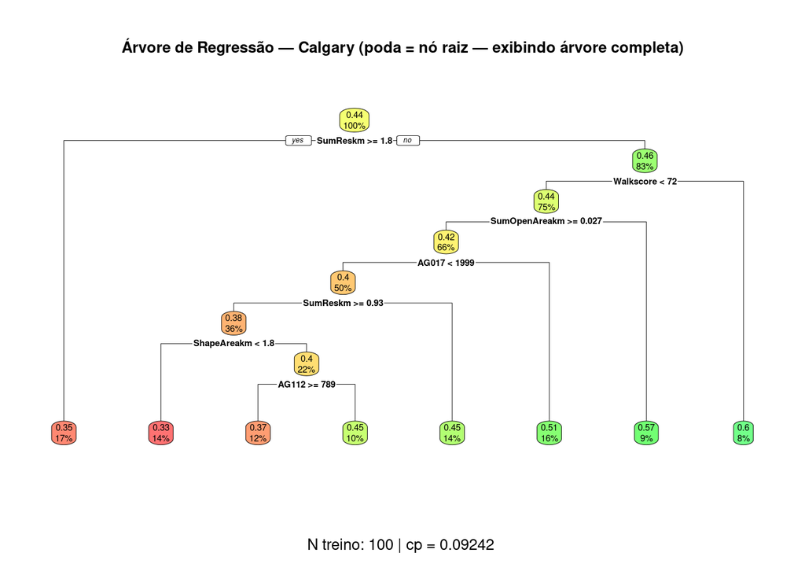

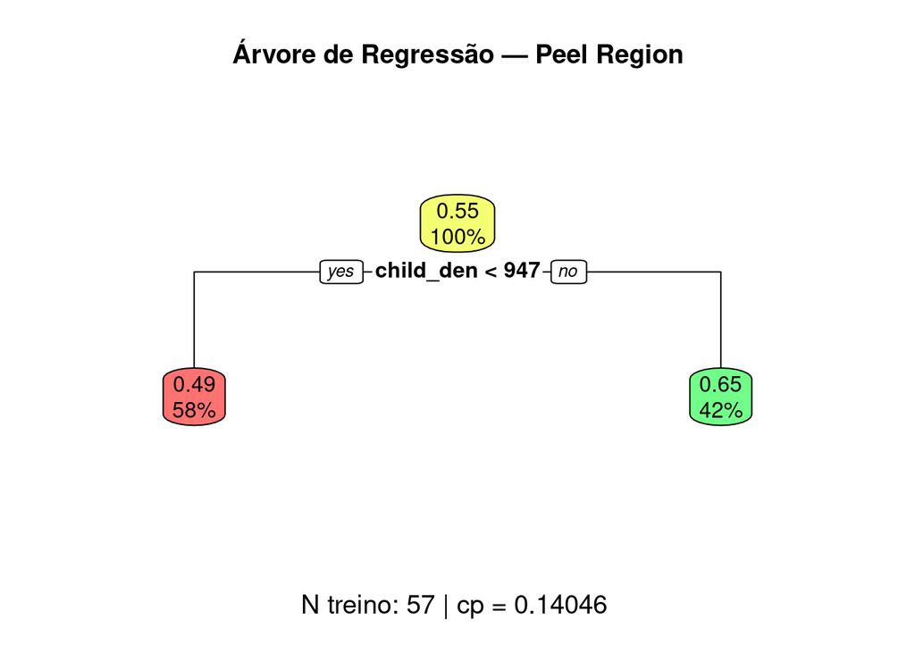

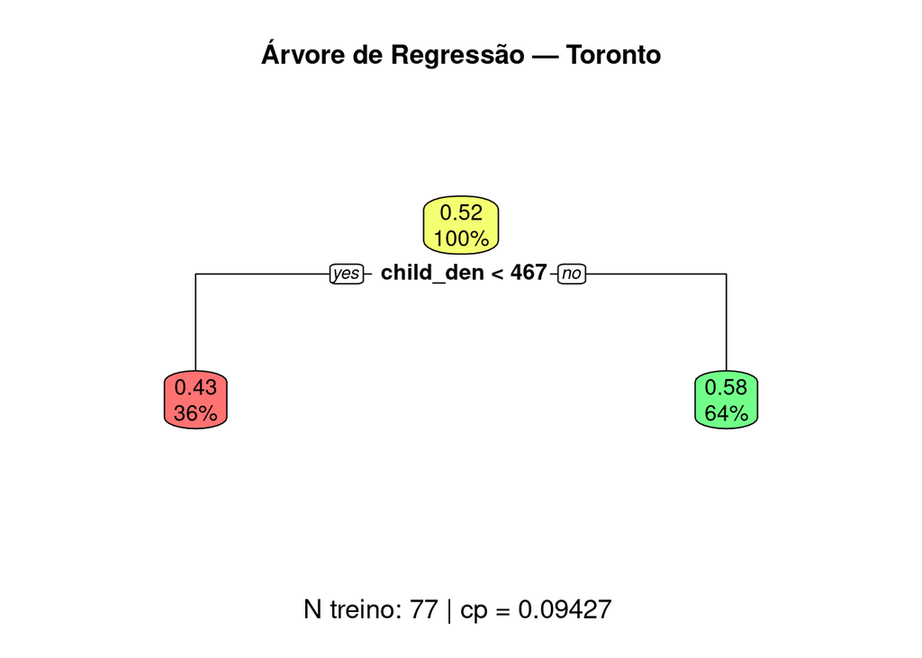

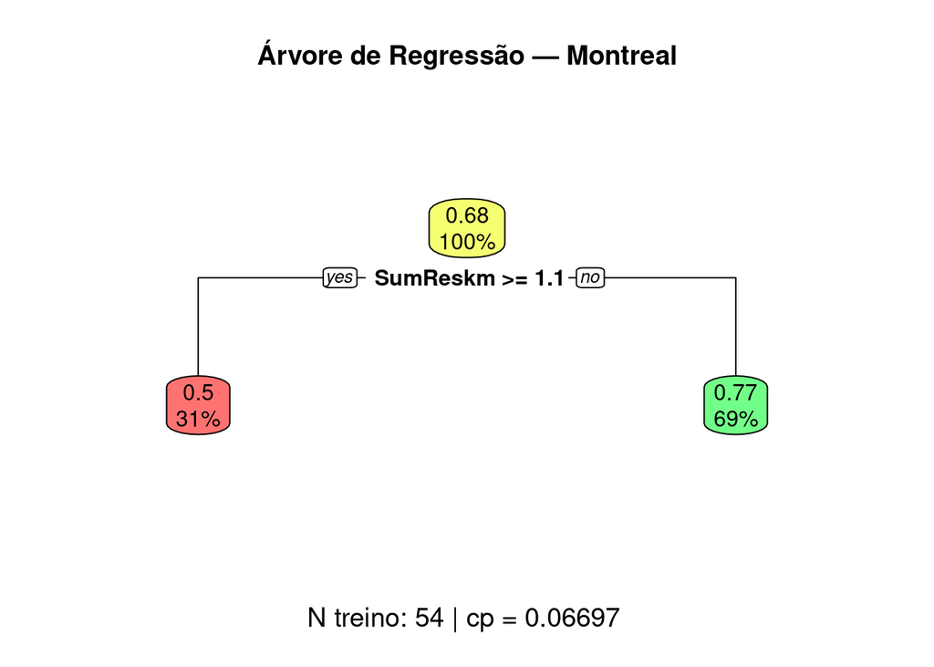

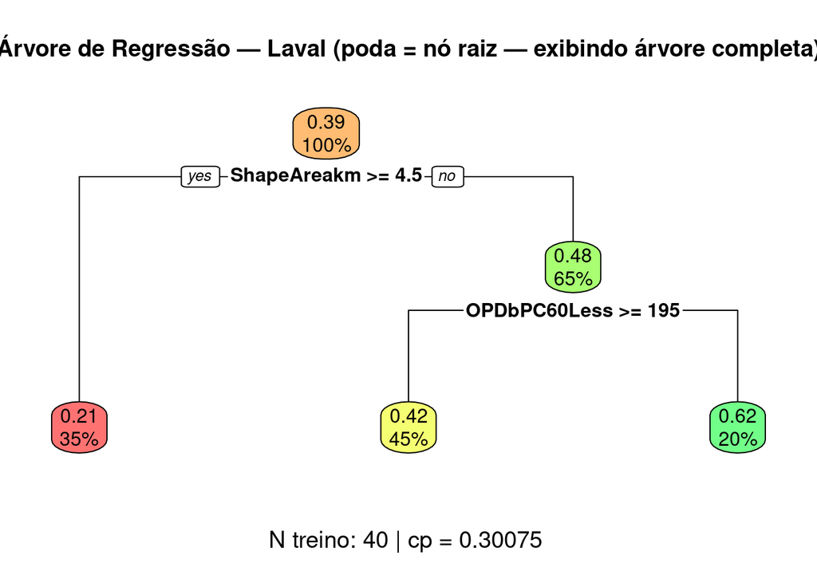

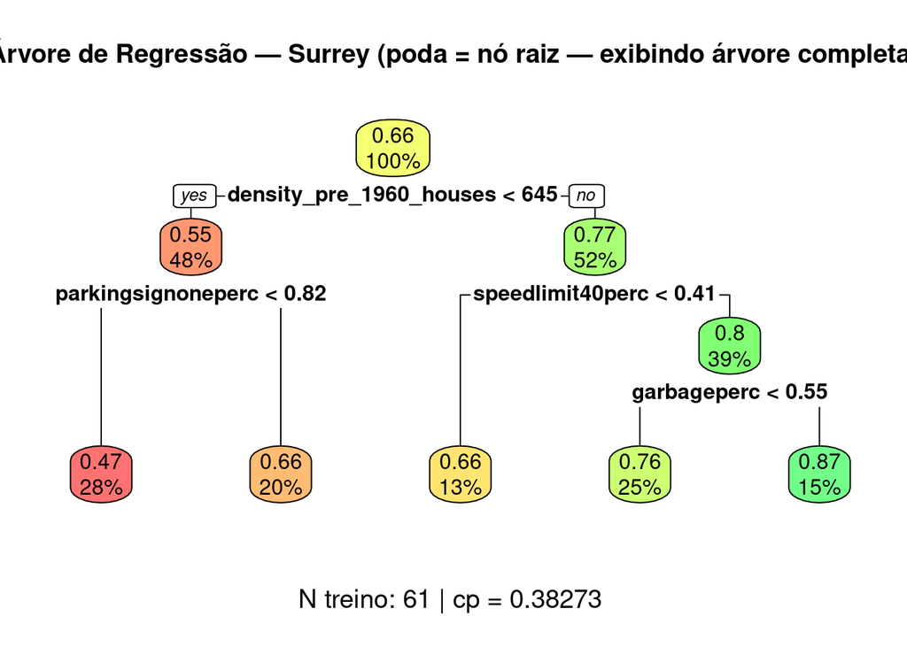

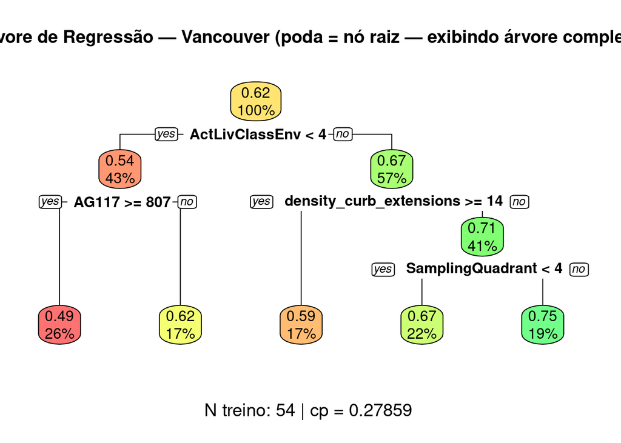